# Matching Methods

Alison Telford

2023-01-10

# Definition

[Stuart (2010)](https://www.ncbi.nlm.nih.gov/pmc/articles/PMC2943670/pdf/nihms200640.pdf) defines matching to be “any method that aims to equate (or”balance”) the distribution of covariates in the treated and control groups”.

# Motivation for Matching

Let’s say we want to test the hypothesis that how cloudy it is outside effects the number of ice cream sales on a single day. We have collected the following data:

| N | Cloudy |
| --- | --- |
| 32 | No |
| 1 | Yes |
| 0 | Yes |
| 27 | No |
| 2 | Yes |
| 0 | Yes |
| 30 | No |
| 18 | No |
| 19 | No |
| 3 | Yes |
| 1 | Yes |
| 1 | Yes |
| 21 | No |
| 20 | No |
| 0 | Yes |
| 24 | No |
| 26 | No |
| 1 | Yes |
| 27 | No |
| 0 | Yes |

As you can see, we managed to collect data on the number of ice cream sales for 10 cloudy days and 10 non-cloudy days. We can plot the data as box plots below:

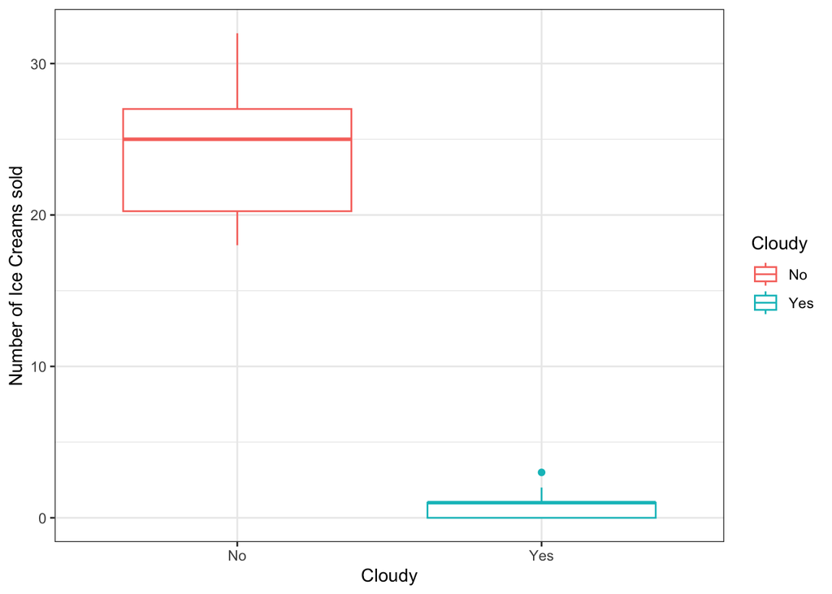

Clearly, there is strong evidence to suggest that the number of ice cream sales per day is definitely effected by how cloudy it is outside.

To test this statistically, we can perform a two sample Wilcox Test (not a t-test here as our data is not quite normally distributed). Our null hypothesis is that the means of the two groups are the same. We can perform this test in R using the following code:

```r
Cloudy = IceCream %>%
  filter(Cloudy == "Yes") %>%
  pull(N)

NotCloudy = IceCream %>%
  filter(Cloudy == "No") %>%
  pull(N)

wilcox.test(Cloudy, NotCloudy, paired = FALSE)
```

```
##
##  Wilcoxon rank sum test with continuity correction
##
## data:  Cloudy and NotCloudy
## W = 0, p-value = 0.0001621
## alternative hypothesis: true location shift is not equal to 0
```

Performing this test gives a p-value of 0.0001621, thus we can conclude that the cloudier the weather, the less ice creams are sold.

### So what’s the problem?

What if I now gave you some more information. Whilst we were recording the data, we also made note of the month in which we counted the number of ice cream sales for each day.

| N | Cloudy | Month |
| --- | --- | --- |
| 32 | No | August |
| 1 | Yes | January |
| 0 | Yes | January |
| 27 | No | August |
| 2 | Yes | January |
| 0 | Yes | January |
| 30 | No | August |
| 18 | No | August |
| 19 | No | August |
| 3 | Yes | January |
| 1 | Yes | January |
| 1 | Yes | January |
| 21 | No | August |
| 20 | No | August |
| 0 | Yes | January |
| 24 | No | August |
| 26 | No | August |
| 1 | Yes | January |
| 27 | No | August |
| 0 | Yes | January |

So what’s wrong with our conclusion? Well, does how cloudy it is really affect how many ice creams are sold? If we had a bright sunny day in January, would we expect the same numbers of ice creams sold on a non-cloudy day in August? Probably not.

So how can we still test our hypothesis? We’re pressured on time so we can’t go and collect more data, what can we do? Well, the good news is we have seen that another study group has also collected data and has recorded the number of ice creams sold per day, whether it was cloudy or not and the month at time of collection. They have lots of data, specifically on the number of ice cream sales per day on cloudy days in the month of August. So we can perform “Matching”.

# Types of Matching

There are many different types of matching described in the literature (to go through all of them would be a PhD thesis in itself). For this page I shall focus on Exact Matching and it’s offspring Coarsened Exact Matching (CEM).

## Exact Matching

### Step 1: Define “closeness”

For Exact Matching, the distance measure between two individuals $i$ and $j$ is defined as:
$$D_{ij} =
\begin{cases}
0,~~~~~ \textrm{if } X_i = X_j\\
\infty, ~~~ \textrm{if } X_i \neq X_j
\end{cases}$$

Essentially, we only consider two individuals to be matched if they have identical covariate values.

Now, the next question is how we decide which covariates to match on. Ideally all covariates related to both the outcome and the variable of interest should be considered in the definition of the distance measure.

Never use the outcome variable in the definition for matching. Variables should ideally be chosen prior to any knowledge on the outcome.

For Exact Matching, the more variables chosen to match on, means you are less likely to obtain matches and therefore you would end up throwing away much of your data. So ensure you select the variables you feel are most related to the outcome and variable of interest.

#### Ice Cream Example

The study owners have decided to perform matching on the Month variable. They believe this variable is directly related to whether it is cloudy outside as well as the number of ice cream sales recorded per day.

### Step2: Implement a Matching Method

Probably the easiest and most common matching method is the “k:1 Nearest Neighbour Matching”. Breaking this down, “k:1” means that we would select k matched individuals to every one individual in our sample. “Nearest Neighbour” refers to selecting individuals who have the smallest distance between itself and those in our sample. For exact matching this essentially means those with the same covariate values.

#### How do we choose k?

The choice of k would depend on a number of factors;

- What final analysis are you planning to perform? Will increasing your sample size increase the power of your test?
- How many “good” matches per observation. For some distance measures (not including Exact Matching) including more than one match is only including further matches with a larger distance away and could be adding poor matches into your sample leading to the introduction of bias.

However, for exact matching, k does not need to be specified as all your matches will be “good”. Thus including all matches will not remove value to the analysis.

#### Ice Cream Example

We could do the matching by hand, but we shall instead take advantage of a package called “MatchIt” in R.

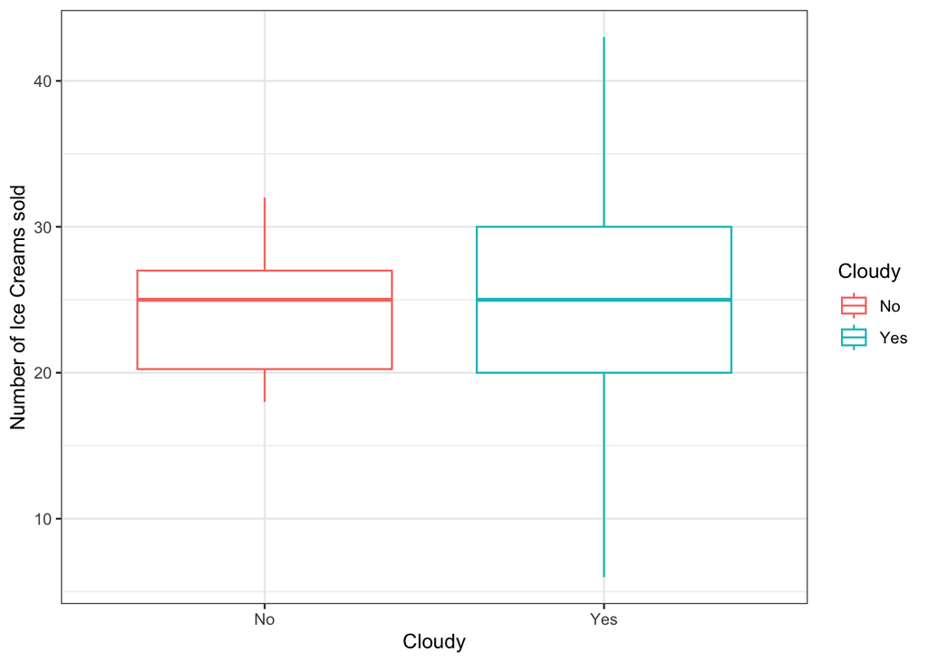

```r
set.seed(1)
Additional_IceCream = data.frame(N = round(rnorm(100, 24, 8)),
                                 Cloudy = rep("Yes", 100),
                                 Month = rep("August", 100))

IceCream_Merged = IceCream %>%
  bind_rows(Additional_IceCream) %>%
  mutate(Month = as.factor(Month))

MatchedIceCream = match.data(matchit(Cloudy ~ Month,
                                 data = IceCream_Merged,
                                 method = "exact")) %>%
  dplyr::select(N, Cloudy, Month)

ggplot(MatchedIceCream, aes(x = Cloudy, y = N, color = Cloudy)) +
  geom_boxplot() +
  labs(y = "Number of Ice Creams sold") +
  theme_bw()
```

Finally, we can perform the Wilcox Test once more:

```r
Cloudy = MatchedIceCream %>%
  filter(Cloudy == "Yes") %>%
  pull(N)

NotCloudy = MatchedIceCream %>%
  filter(Cloudy == "No") %>%
  pull(N)

wilcox.test(Cloudy, NotCloudy, paired = FALSE)
```

```
##
##  Wilcoxon rank sum test with continuity correction
##
## data:  Cloudy and NotCloudy
## W = 529, p-value = 0.7666
## alternative hypothesis: true location shift is not equal to 0
```

and obtain a p-value of 0.77. Thus we cannot reject the null hypothesis and conclude that cloudy weather does not affect ice cream sales.

## Coarsened Exact Matching (CEM)

### Motivation

So we’ve seen how exact matching works. But let’s back track to the start of our Ice Cream example and consider that instead of recording the Month in which we counted the number of sales of Ice Cream per day and noted whether it was a cloudy day, we recorded the temperature in degrees fahrenheit. Thus our data is now

| N | Cloudy | Temperature |
| --- | --- | --- |
| 32 | No | 70 |
| 1 | Yes | 39 |
| 0 | Yes | 42 |
| 27 | No | 83 |
| 2 | Yes | 36 |
| 0 | Yes | 45 |
| 30 | No | 78 |
| 18 | No | 68 |
| 19 | No | 80 |
| 3 | Yes | 33 |
| 1 | Yes | 34 |
| 1 | Yes | 49 |
| 21 | No | 76 |
| 20 | No | 86 |
| 0 | Yes | 34 |
| 24 | No | 72 |
| 26 | No | 74 |
| 1 | Yes | 42 |
| 27 | No | 71 |
| 0 | Yes | 38 |

If we were to repeat the Exact Matching using the following R code:

```r
set.seed(10)
sim_data = round(mvrnorm(n=100, mu = c(10, 60), Sigma = matrix(c(144, 119, 119, 100), nrow = 2)))

Additional_IceCream = data.frame(N = ifelse(sim_data[,1] < 0, 0, sim_data[,1]),
                                 Cloudy = rep("Yes", 100),
                                 Temperature = sim_data[,2])

IceCream_Merged = IceCream_withTemp %>%
  bind_rows(Additional_IceCream)

MatchedIceCream = match.data(matchit(Cloudy ~ Temperature,
                                     data = IceCream_Merged,
                                     method = "exact")) %>%
  dplyr::select(N, Cloudy, Temperature)

kbl(MatchedIceCream, align = 'c', booktabs = T) %>%
  kable_styling(bootstrap_options = "striped")
```

|  | N | Cloudy | Temperature |
| --- | --- | --- | --- |
| 1 | 32 | No | 70 |
| 8 | 18 | No | 68 |
| 16 | 24 | No | 72 |
| 17 | 26 | No | 74 |
| 19 | 27 | No | 71 |
| 23 | 26 | Yes | 74 |
| 27 | 25 | Yes | 72 |
| 45 | 26 | Yes | 72 |
| 48 | 20 | Yes | 70 |
| 55 | 26 | Yes | 74 |
| 63 | 19 | Yes | 70 |
| 81 | 25 | Yes | 72 |
| 83 | 20 | Yes | 68 |
| 90 | 24 | Yes | 74 |
| 93 | 23 | Yes | 70 |
| 99 | 23 | Yes | 70 |
| 109 | 25 | Yes | 71 |
| 116 | 27 | Yes | 74 |

We would obtain a data set where only 5 of the non-cloudy days are matched to cloudy days, thus leaving us with a very small sample size. To overcome this, we can instead use Coarsened Exact Matching.

#### How would Coarsened Exact Matching help?

Recall that we had no issues when matching to months and not temperatures. Why was that? It was simply because there were less values to match on. When we were matching on Month, there would be multiple records in August, therefore there’d be an abundance of potential matches. But for temperatures or indeed any continuous measure, it’s less likely that you’ll have an abundance of records with the exact same value, and in our case, temperature.

So what can we do? Well it’s relatively simple, we simply need to group our temperatures into bins (much like when you’re plotting a histogram or bar chart). For example, we could choose to bin our temperatures into the following bins:

- 30-39
- 40-49
- 50-59
- 60-69
- 70-79
- 80+

Or something else. Choosing the width of the bins can be thought of as a trade off between reintroducing bias and throwing away too much data. We’ve seen what happens if we don’t bin the results (too much data is thrown away), but the opposite end of the scale would be to have a single bin e.g. 30-100 encapsulating all the temperatures. In this scenario, all cloudy days will be compared to non-cloudy days without taking temperature into account, thereby re-introducing the bias of the variable temperature which we’ve seen plays a big part in whether the comparison is significant or not.

Alternatively, the R package MatchIt will calculate the best bins for your data, which is what we shall do for this example.